# School Analysis on Niche

Newbility

November 27, 2018

# Background

Getting accepted into a top college is becoming increasingly difficult. Choosing the best university to attend is even more challenging. We have decided to scrape data from the top 100 colleges in the United States to gain more of an insight on their acceptance trends and student life through quantitative and qualitative (text mining) data visualization.

# Part 1 Datascraping

This section scrapes niche.com for the application and acceptance information on the top 100 colleges according to Niche and puts it into a data frame from which we analyze.

Here we have the top 100 schools in order according to Niche, as well as the structure of the data frame that we created and analyzed.

```
##   [1] "Massachusetts-Institute-of-Technology"
##   [2] "Stanford-University"
##   [3] "Harvard-University"
##   [4] "Yale-University"
##   [5] "Princeton-University"
##   [6] "University-of-Pennsylvania"
##   [7] "Columbia-University"
##   [8] "Duke-University"
##   [9] "Brown-University"
##  [10] "California-Institute-of-Technology"
##  [11] "Washington-University-in-St-Louis"
##  [12] "Rice-University"
##  [13] "University-of-Notre-Dame"
##  [14] "Northwestern-University"
##  [15] "University-of-Chicago"
```

[output cut: 85 more lines]

```
## 'data.frame':    100 obs. of  16 variables:
##  $ School                  : chr  "Massachusetts Institute of Technology" "Stanford University" "Harvard University" "Yale University" ...
##  $ ACT Middle 50%          : chr  "33-35" "31-35" "32-35" "32-35" ...
##  $ SAT Middle 50%          : chr  "1460-1590" "1380-1580" "1430-1600" "1420-1600" ...
##  $ ED/EA                   : chr  "Yes" "Yes" "Yes" "Yes" ...
##  $ Application Fee         : num  75 90 75 80 65 75 85 85 75 75 ...
##  $ Application Deadline    : chr  "January 1" "January 3" "January 1" "January 1" ...
##  $ Undergraduate Population: num  4476 7034 7151 5469 5251 ...
##  $ Acceptance Rate         : num  0.08 0.05 0.05 0.06 0.07 0.09 0.07 0.11 0.09 0.08 ...
##  $ Annual Tuition          : num  21576 16695 16205 18319 17732 ...
##  $ Application Website     : chr  "web.mit.edu" "stanford.edu" "harvard.edu" "yale.edu" ...
##  $ Student:Faculty Ratio   : num  3 10 7 6 5 6 6 7 7 3 ...
##  $ Evening Degree Programs : chr  "No" "No" "Yes" "No" ...
##  $ ACT_MIN                 : num  33 31 32 32 32 32 32 31 31 34 ...
##  $ ACT_MAX                 : num  35 35 35 35 35 35 35 34 34 36 ...
##  $ SAT_MIN                 : num  1460 1380 1430 1420 1400 1380 1410 1380 1370 1510 ...
##  $ SAT_MAX                 : num  1590 1580 1600 1600 1590 1570 1590 1570 1570 1600 ...
```

# Part 2 GGPlot

Next, we used the ggplot2 package to visualize different trends in the data as well as anything that we might have found interesting.

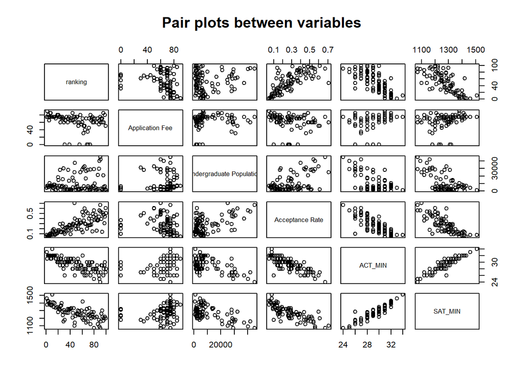

We can see some apparent linear relationship from this pair plot, like `ranking` vs `Acceprance rate` and `ranking` vs `ACT_Min`. We will explore more of their relationships in the following plots.

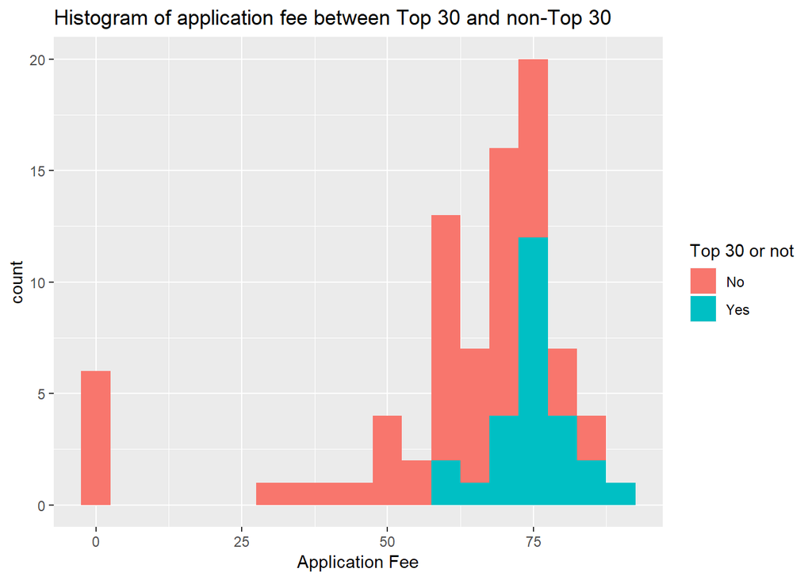

From the histogram we can see that some of the non-Top 30 schools have 0 application fees. Top 30 Schools have an overall higher application fees comparing with non-Top 30 schools and they almost follow a normal distribution.

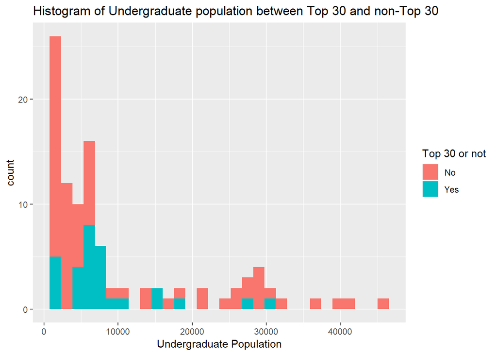

From the histogram we can see that non-Top 30 schools have larger range of undergraduate populations. Top 30 schools dont have undergraduates more than 35,000. Overall Top 30 shcools tend to have small undergraduate populations.

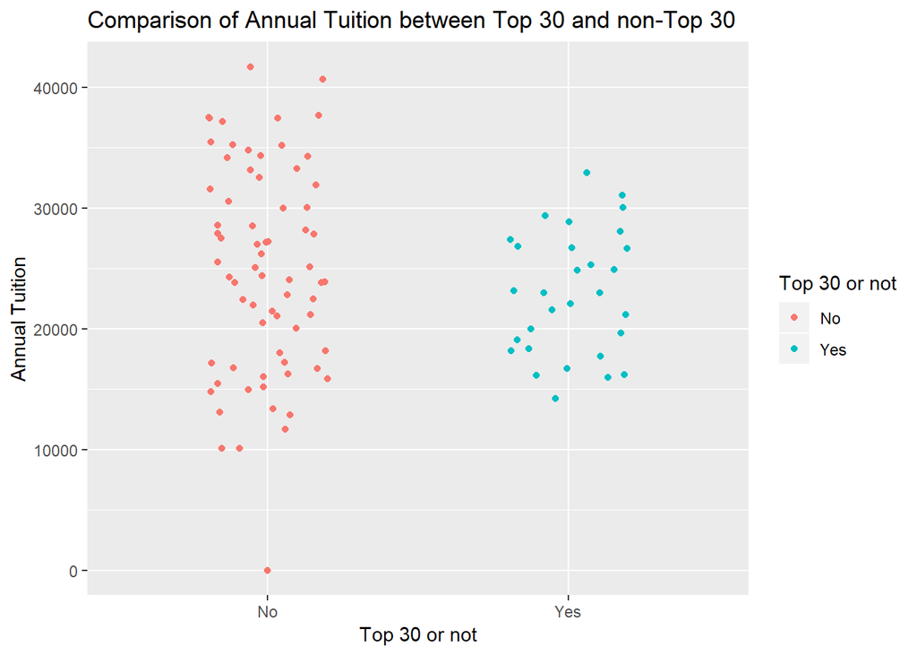

From the jitter plot, we can see that there is no clear relationship bwtween Top 30 schools and non-Top 30 schools. They all have the similar mean of Annual tuition with non-Top 30 have larger tuitions range.

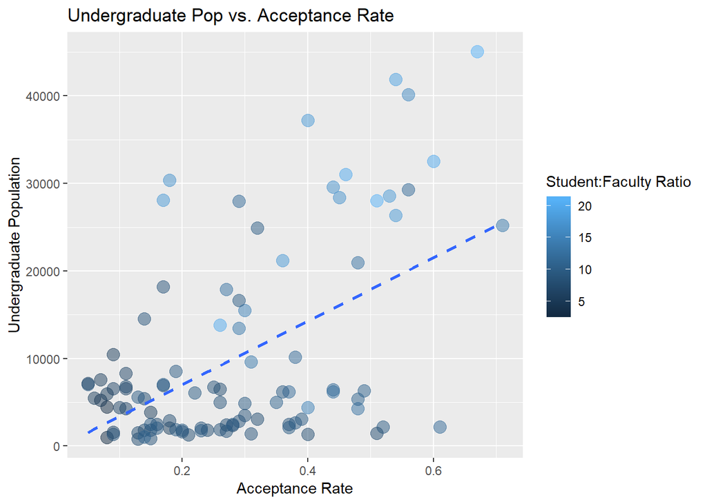

We can see a weak linear relationship between Undergraduate population and Acceptance rate. Lower Student Faculty ratio tend to appear at some schools with lower acceptance rate and lower undergraduate populations.

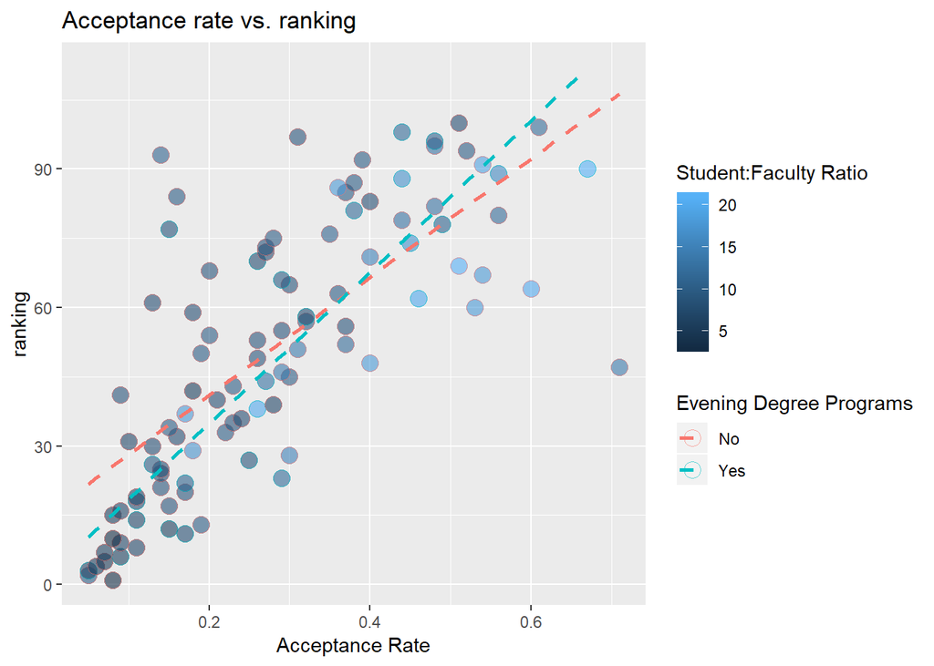

We can see a strong linear relationship between ranking and Acceptance rate. Topper rankings are corresponding with lower Acceptance rate. Student Faculty Ratios and Evening Degree programs appear at different level of schools and no strong relationshops with either ranking or Acceptance Rate.

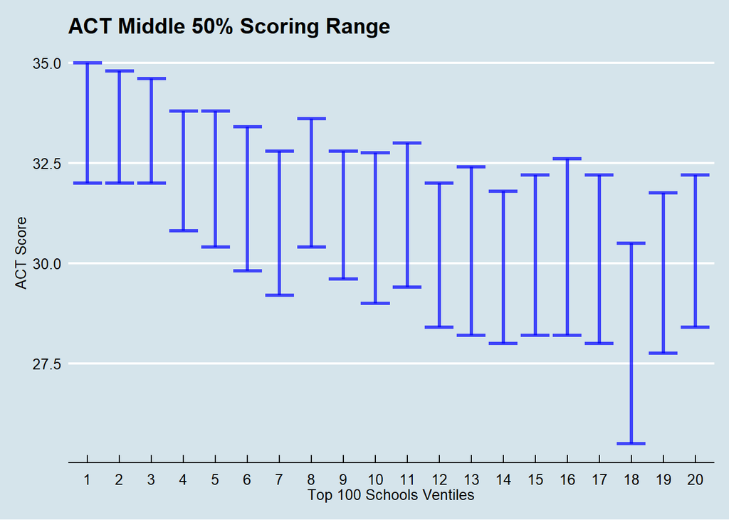

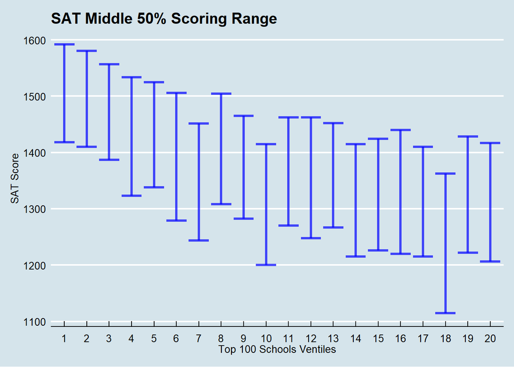

# Part 3 Text Mining

Finally, we know that there is more to colleges than just numbers. We used text mining techniques and sentiment analysis on student reviews to create our own ranking of the schools.

```
## # A tibble: 5,240 x 3
## # Groups:   id [100]
##    id              word        count
##    <chr>           <chr>       <int>
##  1 Amherst College amazing         7
##  2 Amherst College beautiful       6
##  3 Amherst College hard            6
##  4 Amherst College love            4
##  5 Amherst College top             4
##  6 Amherst College fantastic       3
##  7 Amherst College super           3
##  8 Amherst College wonderful       3
##  9 Amherst College competitive     2
## 10 Amherst College friendly        2
## # ... with 5,230 more rows
```

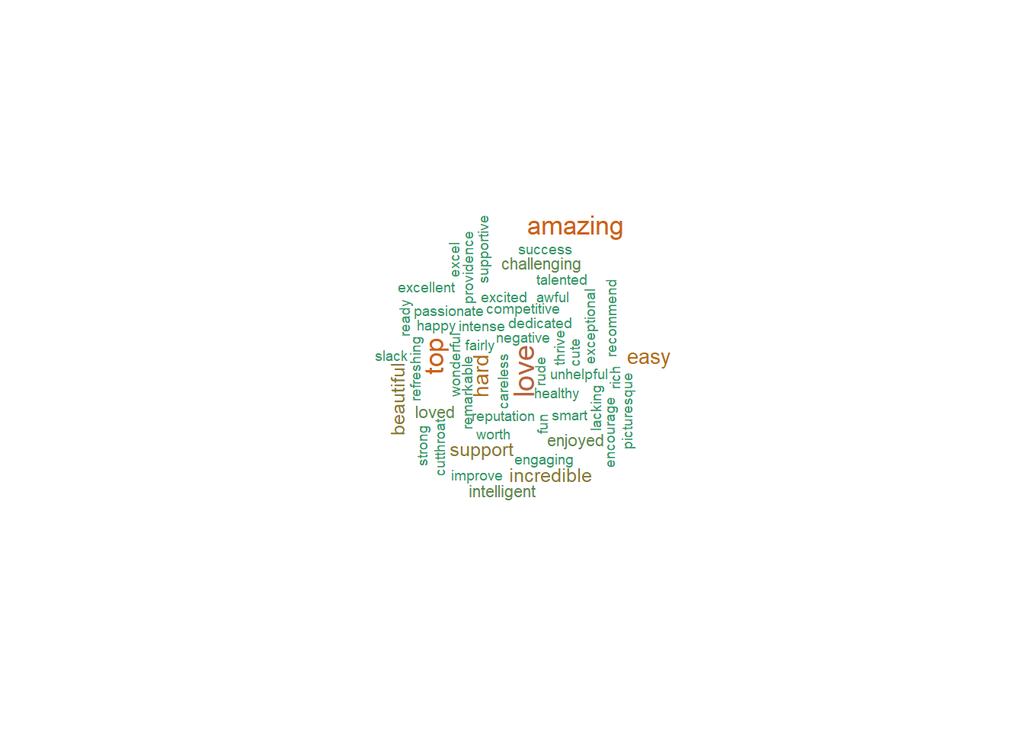

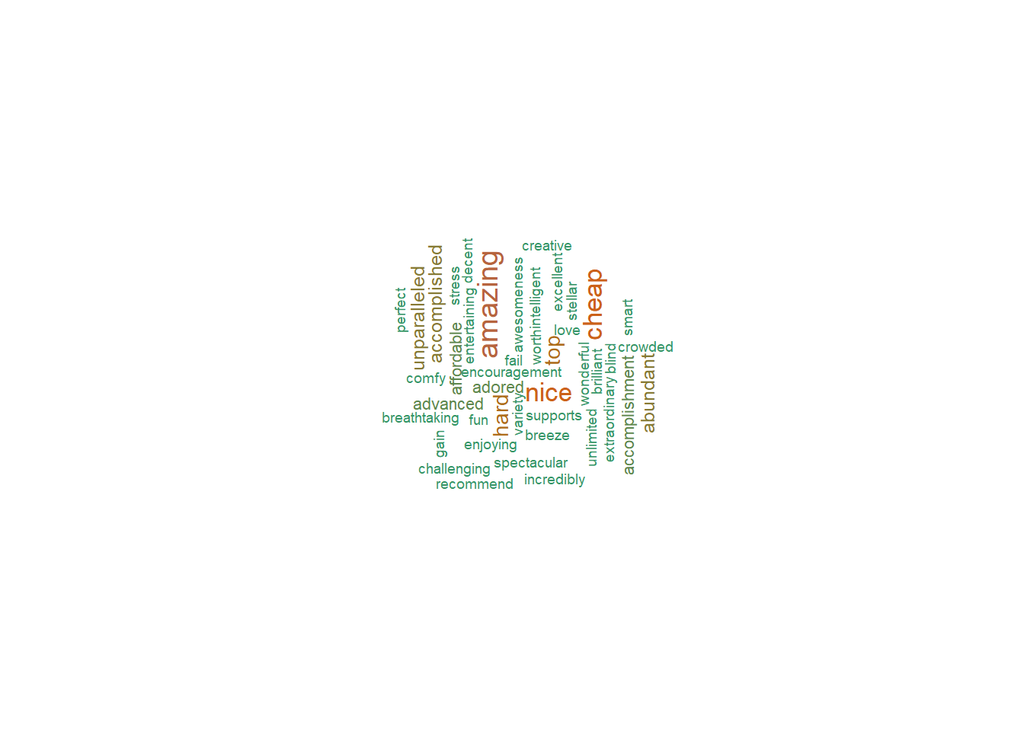

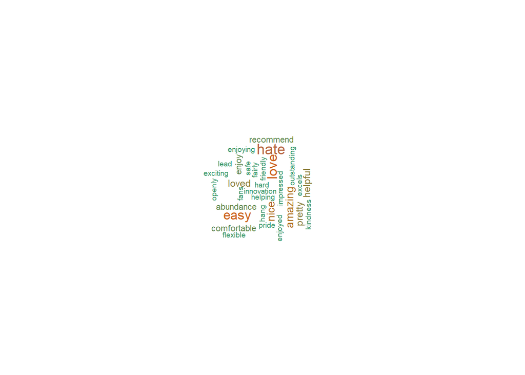

We can see that there is no relationship between schools’ rank and the proportion of negative vs. positive reviews, which we will anaylyze later on.

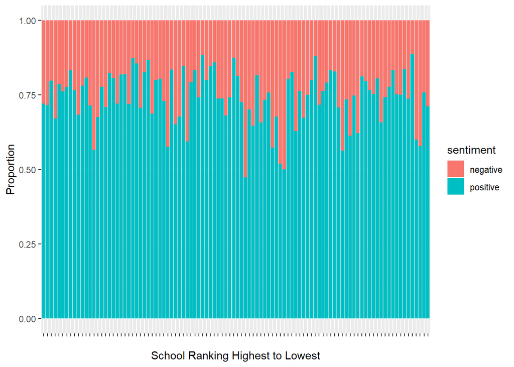

We do the sentiment ananlysis by the sentiment tool “afinn”, which gives each schools a total score(total_score) calculated by the words appeared on the reivew, and we create a data frame to show the new rank(rev_rank) of schools according to their review score. We also include the old rank(ori_rank) from niche.com and its difference(rank_diff) with new rank.

```
##                                                          id ori_rank
## 1                     Massachusetts Institute of Technology        1
## 2                                       Stanford University        2
## 3                                        Harvard University        3
## 4                                           Yale University        4
## 5                                      Princeton University        5
## 6                                University of Pennsylvania        6
## 7                                       Columbia University        7
## 8                                           Duke University        8
## 9                                          Brown University        9
## 10                       California Institute of Technology       10
## 11                       Washington University in St. Louis       11
## 12                                          Rice University       12
## 13                                 University of Notre Dame       13
## 14                                  Northwestern University       14
```

[output cut: 187 more lines]

From the plot we can see that the old rank is not associated with the attitude of their review, becasue the p value of the linear regression have a p-value > 0.05, so we fail to reject the null hypothesis. In general, university students tend to put good reviews about their schools, so their reviews may not be very informative for perspective student.

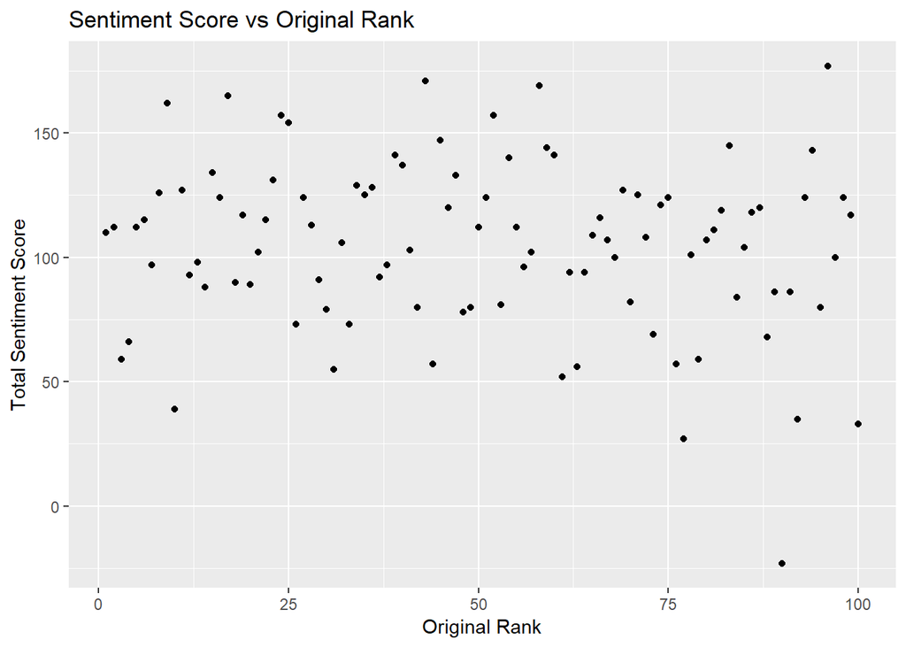

```
##
## Call:
## lm(formula = total_score ~ ori_rank, data = compare_rank)
##
## Residuals:
##      Min       1Q   Median       3Q      Max
## -121.363  -19.724    3.778   21.247   79.612
##
## Coefficients:
##             Estimate Std. Error t value Pr(>|t|)
## (Intercept) 112.9842     6.8784  16.426   <2e-16 ***
## ori_rank     -0.1625     0.1183  -1.374    0.173
## ---
## Signif. codes:  0 '***' 0.001 '**' 0.01 '*' 0.05 '.' 0.1 ' ' 1
##
## Residual standard error: 34.13 on 98 degrees of freedom
## Multiple R-squared:  0.0189, Adjusted R-squared:  0.008885
## F-statistic: 1.888 on 1 and 98 DF,  p-value: 0.1726
```